# sts_campaign

### Individual

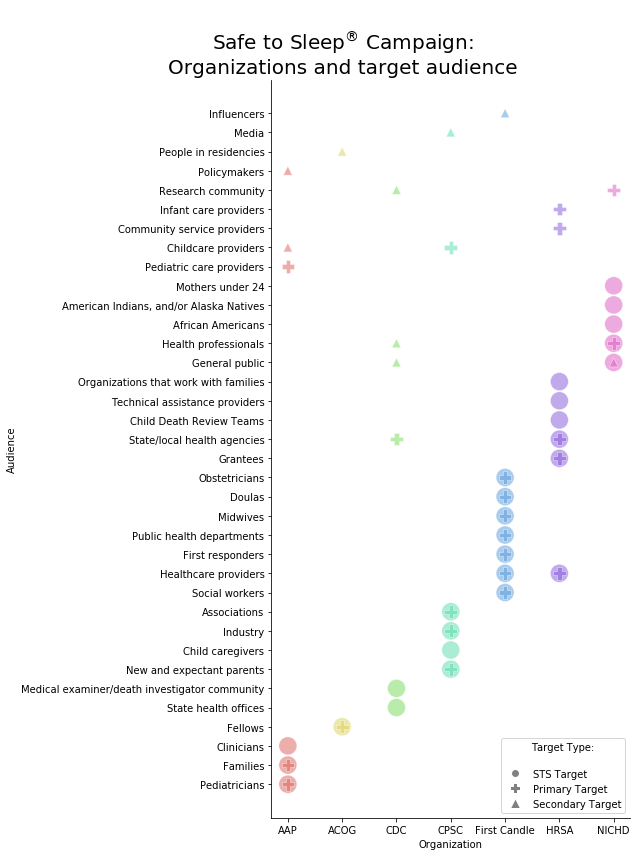

```python
from matplotlib.patches import Patch
from matplotlib.lines import Line2D

columns = ['Audience','weight','Organization','audience']

all_targets = []

i=0
for l in list(sleep_df.iloc[2].values[1:]):
    for m in l:
        all_targets.append([m,10, orgs[i],'STS'])
    i+=1

i=0
for l in list(sleep_df.iloc[0].values[1:]):
    for m in l:
        all_targets.append([m,4, orgs[i], 'Primary'])
    i+=1

i=0
for l in list(sleep_df.iloc[1].values[1:]):
    for m in l:
        all_targets.append([m,1, orgs[i],'Secondary'])
    i+=1


viz = pd.DataFrame(all_targets, columns=columns)
viz = viz[viz['Audience'] != 'None']

fig = plt.figure(figsize=(9,12))
fig.set_tight_layout(True)
plt.title(f"{sts_logo}Organizations and target audience",size=20,loc='center',x=0.2)
# plt.title(f'{check} Campaign:')
ax = plt.subplot(111)
g = sns.scatterplot(data=viz,
                x="Organization",
                y="Audience",
                hue='Organization',
                size="weight",
                style='audience',
                markers =['o','P','^'],
                sizes=(80, 325),
                alpha=.5,
                palette=colors)


legend_elements = [ Line2D([0], [0], marker='o', color='w', label='STS Target',
                          markerfacecolor='gray', markersize=8),
                   Line2D([0], [0], marker='P', color='w', label='Primary Target',
                          markerfacecolor='gray', markersize=10),
                    Line2D([0], [0], marker='^', color='w', label='Secondary Target',
                          markerfacecolor='gray', markersize=10)]

lgnd = ax.legend(handles=legend_elements, loc='lower right',title="Target Type:\n")


# lgnd.legendHandles[0].set_pos

# Hide the right and top spines
ax.spines['right'].set_visible(False)
ax.spines['top'].set_visible(False)

# Only show ticks on the left and bottom spines
ax.yaxis.set_ticks_position('left')
ax.xaxis.set_ticks_position('bottom')
plt.savefig(f'final_visual/target_scatter.png', dpi=300)
plt.show()
```

## Outreach

```
Average Clustering: 0.0
Density: 0.045068027210884355
```

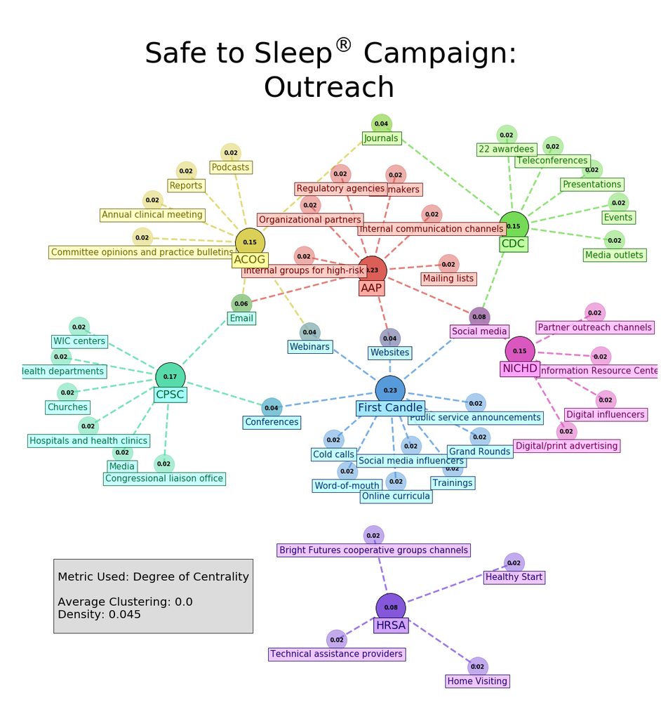

```python
# create the adj_matrix list
col_org_list = list(zip(list(range(1,8)),orgs))
big_m =[]
for i,org in col_org_list:
    for val in sleep_df.iloc[3].values[i]:
        small_m = [org,val]
        big_m.append(small_m)

file_name ='outreach_centrality'
G = create_adjacency_matrix(big_m,file_name)

print(f"Average Clustering: {average_clustering(G)}")
print(f"Density: {nx.density(G)}")

# Begin Visualization
fig = plt.figure(figsize=(20,20))
plt.suptitle(f'{sts_logo}Outreach',size=15,color='black',fontsize=50)
plt.tight_layout()
# draw edges
pos = nx.kamada_kawai_layout(G,center=(0,0),scale=1.5)


# Customize positions for outlier nodes:
for v in sleep_df.iloc[3].values[6]:
    pos[v] = [pos[v][0],pos[v][1]-1.4]
pos[orgs[5]] = [pos[v][0]+.25,pos[v][1]+.2]

for v in sleep_df.iloc[3].values[7]:
    if v != 'Social media':
        pos[v] = [pos[v][0]-.35,pos[v][1]]

    if 'Information' in v or 'Partner' in v:
        pos[v] = [pos[v][0]-.12,pos[v][1]]

pos['Journals'] = [pos['Journals'][0],pos['Journals'][1]+.5]

for i in range(1,8):
    edges=G.edges(orgs[i-1])
    nx.draw_networkx_edges(G,pos=pos,
                           style='dashed',
                           width=3,
                           arrow=False,
                           edgelist=edges,
                           edge_color=[colors[i-1] for n in edges],
                           alpha=.8)

for i in range(1,8):
#     nx.draw_networkx_nodes(G,pos,nodelist=sleep_df.iloc[3].values[i],node_color='black',node_size=1500,alpha=1)
#     nx.draw_networkx_nodes(G,pos,nodelist=sleep_df.iloc[3].values[i],node_color='white',node_size=1300,alpha=1)
    nx.draw_networkx_nodes(G,pos,nodelist=sleep_df.iloc[3].values[i],node_color=[colors[i-1]],node_size=1300,alpha=.5)

for i in range(1,8):
    nx.draw_networkx_nodes(G,pos,nodelist=[orgs[i-1]],node_color='black',node_size=2700,alpha=1)
    nx.draw_networkx_nodes(G,pos,nodelist=[orgs[i-1]],node_color=[colors[i-1]],node_size=2500,alpha=1)

node_count = {}
special_nodes = []
for val in list(G.nodes):
    n = len(G.edges(val))
    if n < 10 and n>1:
        special_nodes.append(val)
    if n == 1:
        n = ''
    node_count[val] = n
centrality_labels = degree_centrality(G)
for k in list(centrality_labels.keys()):
    centrality_labels[k] = round(centrality_labels[k], 2)
nx.draw_networkx_labels(G,pos=pos,font_size=10,labels=centrality_labels,font_weight='bold',font_color='black')

for k in pos:
    pos[k] = [pos[k][0],pos[k][1]-.09]

for i in range(1,8):
    org_labels = {}
    for val in sleep_df.iloc[3].values[i]:
        if val not in orgs:
            org_labels[val] = val
    nx.draw_networkx_labels(G,pos=pos,font_size=15,labels=org_labels,font_color=darken(colors[i-1],.4),bbox=dict(facecolor=lighten(colors[i-1],.4),alpha=.85,edgecolor=darken(colors[i-1],.5)))

for k in pos:
    pos[k] = [pos[k][0],pos[k][1]-.02]

for i in range(1,8):
    org_labels = {}
    org_labels[orgs[i-1]] = orgs[i-1]
    nx.draw_networkx_labels(G,pos=pos,font_size=19,labels=org_labels,font_color=darken(colors[i-1],.45),bbox=dict(facecolor=lighten(colors[i-1],.3),alpha=1,edgecolor=darken(colors[i-1],.5)))

plt.annotate(
s = f"\n Metric Used: Degree of Centrality \n\n Average Clustering: {round(average_clustering(G),3)} \n Density: {round(nx.density(G),3)} \n",
xy=(-1.5, -1.5),
va='top',
ha='left',
fontsize = 20,
bbox=dict(facecolor='lightgray', alpha=.8,pad=.5,),
)


plt.axis('off')
plt.savefig(f'final_visual/{file_name}.png',dpi=300)
plt.show()
```

## Assets

```python
asset_lists = list(sleep_df.iloc[6].values[1:])
asset_lists_reduced = [['Education/Training',
  'Daily briefing with AAP members',
  'Hospital associations',
  'Mailing lists',
  'Publications',
  'Periodic survey',
  'Webpages'],
 ['Annual clinical meeting',
  'E-Learning',
  'Committee opinions and practice bulletins',
  'Publications',
  'Digital media',
  'Toolkits',
  'Webinars'],
 ['Clinician materials',
  'Grand Rounds',
  'Monthly presentations',
  'Publications',
  'Presentations for professional conferences',
  'SUID and SDY Case Registry/vital statistics',
  'Webpages'],
 ['Partner listserv',
  'Videos'],
 ['Education/Training',
  'Conferences',
  'Digital partnerships',
  'Educational materials',
  'Grand Rounds',
  'Guardian program',
  'PSAs',
  'Videos',
  'E-Learning',
  'Webinars'],
 ["Toolkits",
  'MCHB Challenges',
  "Educational materials"],
 ['Digital media',
  'Publications',
  'Toolkits',
  'Education/Training',
  'Videos',
  'Webinars']]
all_asset_lists = [i for j in asset_lists_reduced for i in j ]
assets_dict = {orgs[i]:asset_lists_reduced[i] for i in range(len(orgs))}
AG = nx.Graph(assets_dict)
```

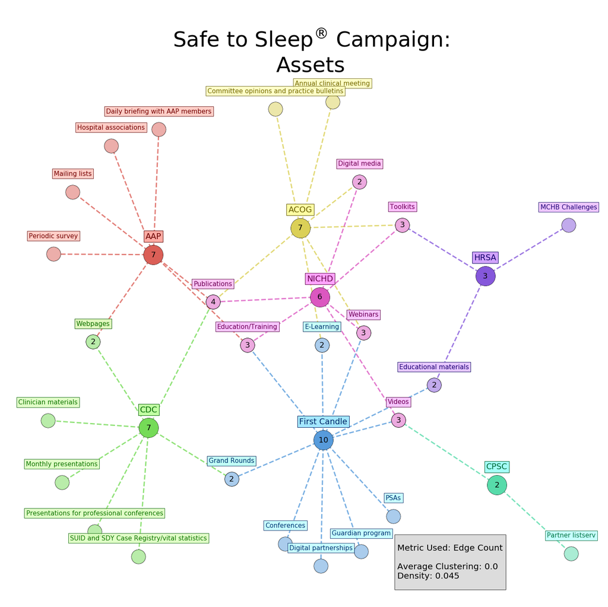

```python
plt.figure(figsize=(20,20))
plt.title(f'{sts_logo}Assets',size=15,color='black',fontsize=50)
plt.tight_layout()
post=nx.kamada_kawai_layout(AG)
AG = nx.Graph(assets_dict)
for i,org in enumerate(orgs):
    #add org nodes
    nx.draw_networkx_nodes(AG,post,
                   nodelist=[org],
                   node_color=[colors[i]],
                   node_size=2000,
               alpha=1)
    #add asset nodes
    nx.draw_networkx_nodes(AG,post,
                   nodelist=asset_lists_reduced[i],
                   node_color=[colors[i]],
                   node_size=1000,
               alpha=0.5)
    #add all edges
    edges=AG.edges([orgs[i]])
    nx.draw_networkx_edges(AG,pos=post,
                           style='dashed',
                           width=3,
                           arrow=False,
                           edgelist=edges,
                           edge_color=[colors[i] for n in edges],
                           alpha=.8)
    #add additional features to asset nodes
    nx.draw_networkx_nodes(AG,post,
                           nodelist=asset_lists_reduced[i],
                           node_color='black',
                           node_size=1100,
                           alpha=1)
    nx.draw_networkx_nodes(AG,post,
                           nodelist=asset_lists_reduced[i],
                           node_color='white',node_size=1000,
                           alpha=1)
    nx.draw_networkx_nodes(AG,post,
                           nodelist=asset_lists_reduced[i],
                           node_color=[colors[i]],
                           node_size=1000,
                           alpha=.5)
    #add additional features to org nodes
    nx.draw_networkx_nodes(AG,post,
                           nodelist=[org],
                           node_color='black',
                           node_size=2100,alpha=1)
    nx.draw_networkx_nodes(AG,post,
                           nodelist=[org],
                           node_color=[colors[i]],
                           node_size=2000,
                           alpha=1)
node_count = {}
for val in list(AG.nodes):
    if len(AG.edges(val))>1:
        node_count[val] = len(AG.edges(val))
nx.draw_networkx_labels(AG,pos=post,
                        font_size=18,
                        labels=node_count,
                        font_color='black')


for k in post:
    post[k] = [post[k][0],post[k][1]+.05]

for i in range(1,8):
    org_labels = {val:val for val in asset_lists_reduced[i-1]}
    nx.draw_networkx_labels(AG,pos=post,
                            font_size=15,
                            labels=org_labels,
                            font_color=darken(colors[i-1],.4),
                            bbox=dict(facecolor=lighten(colors[i-1],.4),
                                      alpha=.85,edgecolor=darken(colors[i-1],.5)))

for i in range(1,8):
    org_labels = {}
    org_labels[orgs[i-1]] = orgs[i-1]
    nx.draw_networkx_labels(AG,pos=post,
                            font_size=19,
                            labels=org_labels,
                            font_color=darken(colors[i-1],.45),
                            bbox=dict(facecolor=lighten(colors[i-1],.3),
                                      alpha=1,edgecolor=darken(colors[i-1],.5)))

plt.annotate(
s = f"\n Metric Used: Edge Count \n\n Average Clustering: {round(average_clustering(G),3)} \n Density: {round(nx.density(G),3)} \n",
xy=(.4, -.5),
va='top',
ha='left',
fontsize = 20,
bbox=dict(facecolor='lightgray', alpha=.8,pad=.5,),
)

plt.axis('Off')
plt.savefig('final_visual/asset_edgecount.png',dpi=300)
```